# Regression: Foundations

### Sean Trott

### CSS Bootcamp

# High-level learning outcomes of this week

##### [Null Hypothesis Significance Testing (NHST)](https://en.wikipedia.org/wiki/Statistical_hypothesis_testing)

- **Explain** the theoretical foundations
- **Implement** a t-test in Python
- **Evaluate** the result of a given test

##### [Linear regression](https://en.wikipedia.org/wiki/Linear_regression):

- **Implement** using Python
- **Interpret** coefficients, **examine** residuals, and **predict** new data

##### [Beyond linear regression](https://en.wikipedia.org/wiki/Generalized_linear_model):

- **Explain** the motivation for mixed/multilevel models
- **Implement** other families of regression models (e.g., logistic regression)

# Today's focus

- **Explain** the motivation for building statistical models in general.
- **Describe** the basic assumptions (and limitations) of linear regression.
- **Explain** the concept of *prediction error* and why it matters for statistics.
- **Implement** linear regression in Python using `statmodels`.
- **Interpret** coefficients for both *continuous* and *categorical* predictors.

# Part 0: From *Tests* to *Models*

## Intro: Statistical Modeling

- So far, we've focused on **hypothesis tests**.
  - I.e., "Is a difference between groups **significant**?"
- But statistics also gives us tools to **model** our data.
- A "statistical model" is a very powerful and versatile concept:
  - **Prediction**: how can we make better *predictions* of $Y$, given $X$ and parameters $\beta$?
  - **Inference**: what theoretical inferences can we make about the relationship between $X$ and $Y$, given $\beta$?
- NHST philosophy can be applied to interpretation of parameters $\beta$ (coming up later).

## Models as generative

- Statistical models are also **generative**.
- Underlying assumptions:
  - Observed data $X, Y$ was the result of some **data-generating process**.
  - We can't know this process exactly, but we can build a **model** of it.
  - ["All models are wrong, but some are useful"](https://en.wikipedia.org/wiki/All_models_are_wrong).
- This is what allows us to generate *new* output from a statistical model.

## Looking ahead: ML models

- The notion of a "model" is very important for machine learning.
- In [supervised learning](https://en.wikipedia.org/wiki/Supervised_learning), we learn a **function** mapping *input* to *labeled output*.

  $\Large Y = f(X, \beta) + \epsilon$
- **Model fitting** refers to a procedure for finding parameters $\beta$ that lead to the best predictions of $Y$, given $X$.
- One of the simplest and most prevalent models is **linear regression**.

# Part 1: Intro to linear regression

## Linear regression

- Goal: find the **best-fitting** line between $X$ and $Y$.
  - Assuming a linear relationship bewteen inputs $X$ and response $Y$...
  - ...find parameters $\beta$ that minimize **prediction error**.
- Allows for multiple predictor variables (and thus multiple parameters or **coefficients**).

  $\Large Y = \beta_1X_1 + \beta_2X_2 + ... + \beta_nX_n $

## Check-in: why *linear* regression?

## Check-in: why *linear* regression?

**Answer**: Linear regression uses a *linear equation*. It assumes the function between $X$ and $Y$ is *linear*.

$\Large Y = \beta_0 + \beta_1X_1 + \epsilon$

- $\beta_0$, or **intercept**: predicted $\hat{Y}$ when $X_1 = 0$.
- $\beta_1$, or **slope**: predicted increase in $\hat{Y}$ for each 1-unit increase in $X_1$.
  - When $X_1$ is categorical, **slope** (typically) reflects the **difference in means** between categories.
- $\epsilon$, or **error**: assumes normally-distributed "leftover variance".

## Making connections: Regression and NHST

- Our parameters $\beta_0, \beta_1, ..., \beta_n$ are *estimates*.
- Underlying assumption: there is some **truly linear, data-generating process**.
  - We don't know the *true* parameter values––just like we never know the **population parameter**.
  - Instead, we must **estimate** them from a sample.

### Linear equation in action

The linear equation uses parameters $\beta$ to **generate** output $Y$ from input $X$.

- Note 1: This generative model is missing an error term, $\epsilon$.
- Note 2: In practice, these parameters are *learned* from labeled data $[X, Y]$.
- As the plot shows, the output is *linear*.

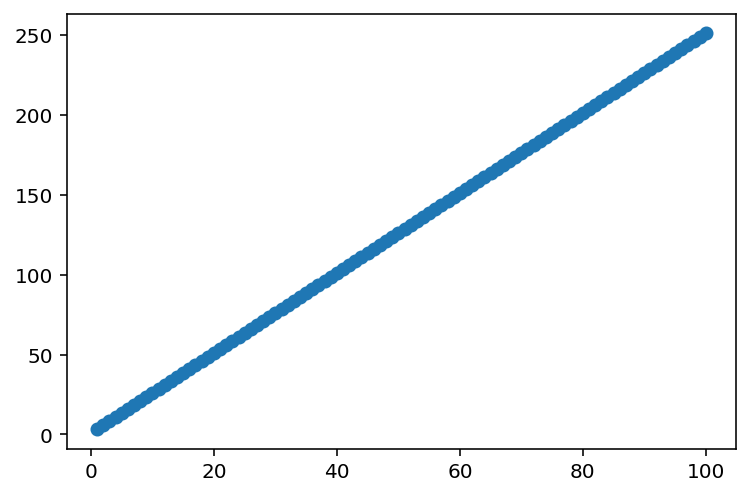

```python
X = np.arange(1, 101) ### Given some inputs X...
beta = 2.5 ### some coefficient
intercept = 1 ### and some intercept
y_pred = X*beta + intercept ### we can generate predictions
plot = plt.scatter(X, y_pred)
```

## Assumption 1: Linearity

- At its core, linear regression assumes a *linear relationship* between $X$ and $Y$.
- This is a very major assumption!
  - Lots of relationships aren't linear.
- This is an example of a model with [**high bias**](https://en.wikipedia.org/wiki/Bias%E2%80%93variance_tradeoff): it makes a strong assumption about functional form.

## Why the linear bias matters

If we fit a linear model to each of [these datasets](https://en.wikipedia.org/wiki/Anscombe%27s_quartet), the slope coefficient would be roughly identical––even though the datasets are clearly very different.

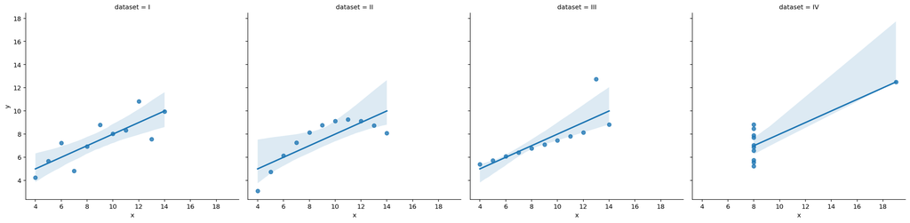

```python
df_anscombe = sns.load_dataset('anscombe')
sns.lmplot(data = df_anscombe,
           x = 'x',
           y = 'y',
           col = 'dataset')
```

### Models do what they're told, even when you don't want them to.

- Even if a non-linear relationship is clear to us, linear regression will always try to find a **linear** relationship.
- In [Statistical Rethinking](https://xcelab.net/rm/statistical-rethinking/), Richard McElreath compares statistical models to ["golems"](https://en.wikipedia.org/wiki/Golem).
  - Powerful machines that follow their instructions *to the letter*.
  - This is also true of traditional hypothesis tests.
- **Note 1: some models (like deep neural networks) have more flexibility, while others (like linear regression), have less.**
  - This is at the heart of the [bias-variance trade-off](https://seantrott.github.io/procrustean_models/).

## What is the "line of best fit"?

- Linear regression tries to find the **best-fitting line** between $X$ and $Y$.

### What does this mean?

# Part 2: Prediction error, residuals, and more

### Many *possible* lines between $X$ and $Y$

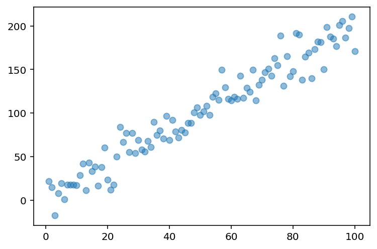

```python
np.random.seed(10)
X = np.arange(1, 101)
Y = X * 2 + np.random.normal(loc = 0, scale = 15, size = 100)
plt.scatter(X, Y, alpha = .5)
```

### Many *possible* lines between $X$ and $Y$

These lines all have the same slope, but have different **intercepts**.

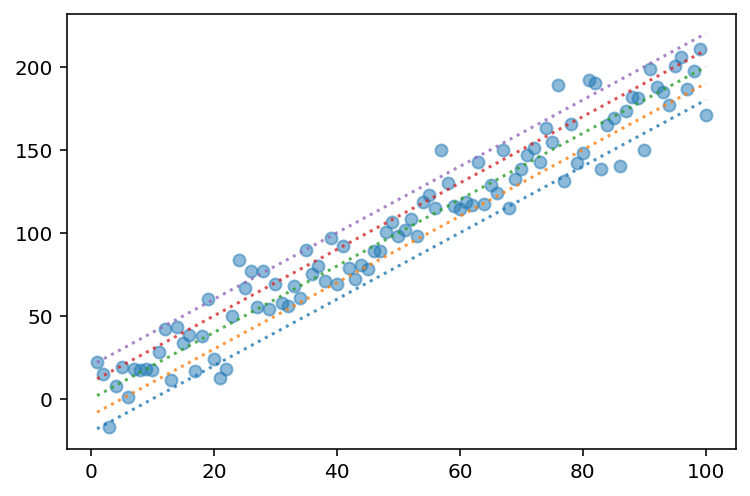

```python
plt.scatter(X, Y, alpha = .5)
for intercept in [-20, -10, 0, 10, 20]:
    y_pred = intercept + X * 2
    plt.plot(X, y_pred, alpha = .8, linestyle = "dotted")
```

### Many *possible* lines between $X$ and $Y$

These lines all *begin* in the same place, but have different **slopes**.

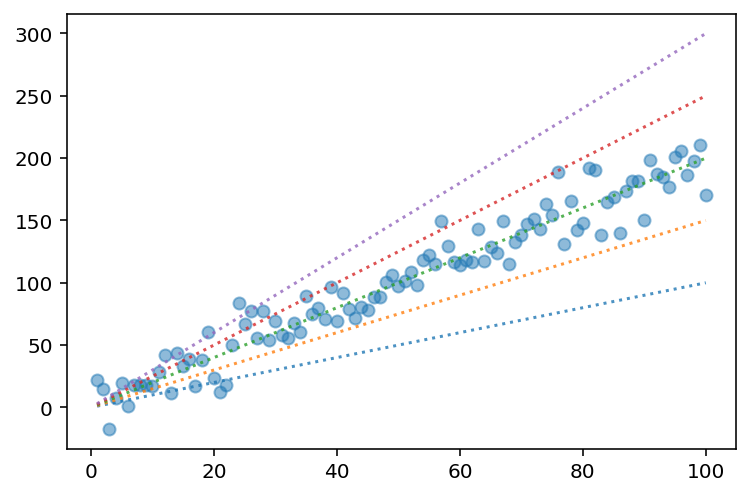

```python
plt.scatter(X, Y, alpha = .5)
for coef in [1, 1.5, 2, 2.5, 3]:
    y_pred = X * coef
    plt.plot(X, y_pred, alpha = .8, linestyle = "dotted")
```

### Clearly, some lines are "better" than others.

- We can quantify **quality of fit** by calculating **prediction error** in some way.
- Simple approach: sum of squared deviations (residuals) between predictions $\hat{Y}$ and actual values $Y$.

  $\Large RSS = \sum_i^N (\hat{y}_i - y_i)^2$

**Does this equation remind you of anything?**

### Analogy: $SS_X$ vs. $RSS$

The **sum of squares of X** is defined as:

- $\Large SS_X = \sum_{i}^{N}(x_i - \mu)^2$

Whereas **RSS** is defined as:

- $\Large RSS = \sum_i^N (\hat{y}_i - y_i)^2$

### Comparing $RSS$ for different lines

- Lowest (best) RSS when $\beta = 2$, which we know was the true parameter value.

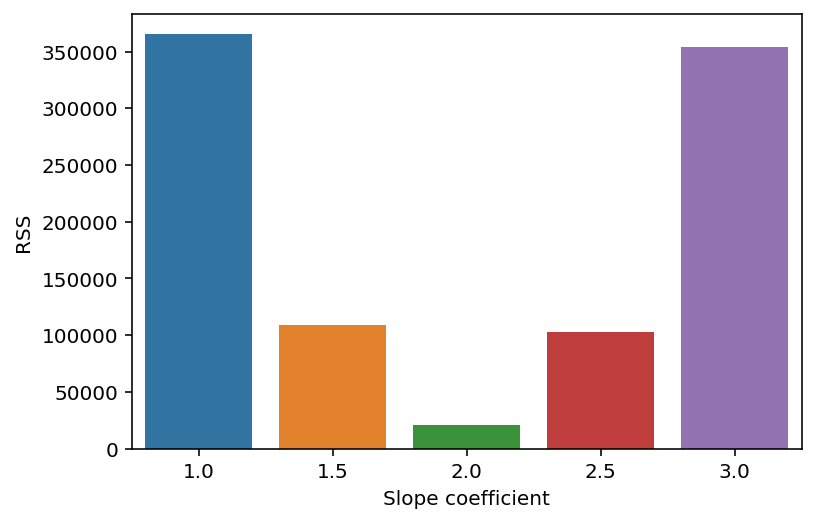

```python
errors = []
for coef in [1, 1.5, 2, 2.5, 3]:
    rss = sum((X * coef - Y)**2) ## Get SSE
    errors.append({'rss': rss, 'slope': coef}) ## Add to dictionary
df_errors = pd.DataFrame(errors)
sns.barplot(data = df_errors, x = 'slope', y = 'rss')
plt.xlabel("Slope coefficient")
plt.ylabel("RSS")
```

## A more interpretable measure

- The **standard error of the estimate** provides a more interpretable measure of prediction error.

  $\Large S_{Y|X} = \sqrt{\frac{RSS}{n-2}}$
- $S_{Y|X}$ tells us (roughly) the **average amount of prediction error**.
  - How much, on average, do we expect $\hat{Y}$ to deviate from $Y$?
  - As before, a smaller number means better fit.

## $S_{Y|X}$ in action (pt. 1)

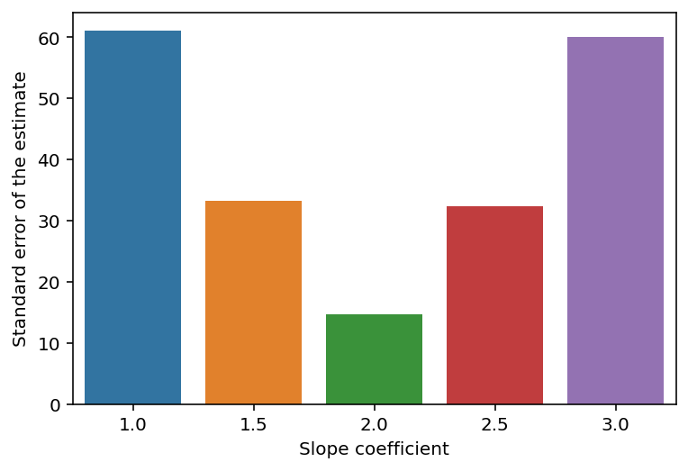

```python
errors = []
for coef in [1, 1.5, 2, 2.5, 3]:
    see = math.sqrt(sum((X * coef - Y)**2)/(len(X)-2)) ## Get SEE
    errors.append({'see': see, 'slope': coef}) ## Add to dictionary
df_errors = pd.DataFrame(errors)
sns.barplot(data = df_errors, x = 'slope', y = 'see')
plt.xlabel("Slope coefficient")
plt.ylabel("Standard error of the estimate")
```

## $S_{Y|X}$ in action (pt. 2)

- $S_{Y|X}$ tells us which parameters yield the best fit.
- We can also use $S_{Y|X}$ to attach **uncertainty** to specific predictions!

## Check-in: what assumption does this make?

More concretely: if we want to attach a CI to our prediction using $S_{Y|X}$, what are we assuming about our **residuals**?

## Check-in: what assumption does this make?

More concretely: if we attach a CI this way to our prediction using $S_{Y|X}$, what are we assuming about our **residuals**?

**Two key assumptions**:

1. Assume that residuals are **normal**, such that we can rely on same $z$-score values to calculate CI.
2. Assume **homoscedasticity**, i.e., residuals are *evenly distributed* along regression line.

## Assumption 2: Normality

**Linear regression assumes normally distributed residuals**.

- This interpretation of $S_{Y|X}$ assumes the **residuals** of linear regression are normally distributed.
- We also assume our **parameter values** $\beta$ are drawn from a normal distribution.
  - Particularly if we want to conduct a **hypothesis test** on those parameters (coming up later).

**What about the variables themselves?**

- Normality of $X$ and $Y$ can *help* with interpretation (i.e., sometimes a very right-skewed distribution "distorts" our understanding of coefficients).
- But it's actually not strictly necessary in a theoretical sense.

## Assumption 3: Homoscedasticity

**Homoscedasticity = residuals are evenly distributed along the regression line**.

- I.e., we assume that **variance in $Y$** is *uncorrelated* with $X$.
- Note that **heteroscedasticity = residuals unevenly distributed along the regression line**.

**This matters for how we interpret $S_{Y|X}$**.

- Recall that $S_{Y|X}$ is an estimate of prediction error.
- If residuals are unevenly distributed, $S_{Y|X}$ will sometimes be more accurate than others.

### Heteroscedasticity in action

Heteroscedastic data often (but not always) has a tell-tale "funnel" shape.

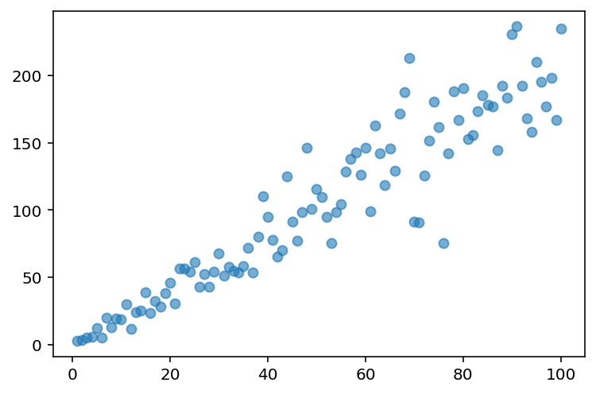

```python
np.random.seed(1)
X = np.arange(1, 101)
y = X *2 + np.random.normal(loc = 0, scale = X/2,
                         size = 100)
plt.scatter(X, y, alpha = .6)
```

### Heteroscedasticity and prediction error

If we plot a regression line, we see that **error** grows as $X$ grows.

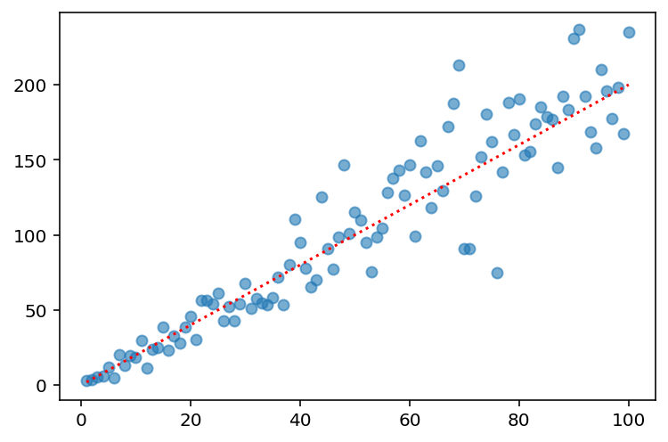

```python
y_pred = X * 2
plt.scatter(X, y, alpha = .6)
plt.plot(X, y_pred,linestyle = "dotted", color = "red")
```

### Heteroscedasticity and prediction error

We can also display this more directly by plotting $\hat{y} - y$ against $X$.

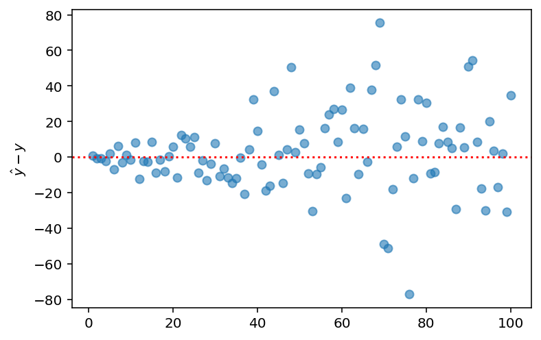

```python
error = (y - y_pred)
plt.scatter(X, error, alpha = .6)
plt.axhline(y = 0, linestyle = "dotted", color = "red")
plt.ylabel("$\hat{y} - y$")
```

### Heteroscedasticity and prediction error

Alternatively, we can look at how **squared error** changes as $X$ increases.

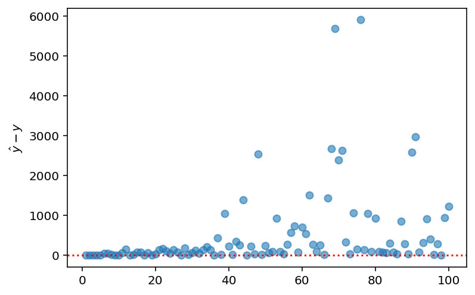

```python
error = (y - y_pred)**2
plt.scatter(X, error, alpha = .6)
plt.axhline(y = 0, linestyle = "dotted", color = "red")
plt.ylabel("$\hat{y} - y$")
```

# Brief interlude: Assumptions of linear regression

## Assumption 4: Independence

- A final assumption of (ordinary least squares) linear regression is **independence**.
- Independence) means that each **event** or *observation* in our dataset if they do not affect each other, i.e., they were generated by distinct processes.
  - An example of **non-independence** would be multiple observations from the same subject.
- In practice, lots of things are not independent.
- This is one reason **multilevel models** are so useful (coming up on Day 5).

## Recap of assumptions

We've discussed four critical assumptions:

1. The relationship between $X$ and $Y$ is **linear**.
2. The residuals are **normally distributed**.
3. The residuals are **homoscedastic**.
4. Our observations are **independent**.

Now, onto linear regression in Python!

# Part 3: Univariate linear regression in Python

## Goals of this section

- Introduction to `statsmodels` package.
- Inspecting and interpreting **coefficients** and their **standard errors**.
- Inspecting and interpreting $R^2$ term.

## Dataset: when do children learn English words?

In this section, we'll be using a dataset I've curated that combines several kinds of information:

- The **average age** at which an English word is learned ([Kuperman et al., 2012](https://link.springer.com/article/10.3758/s13428-012-0210-4)).
- How **concrete** people rate that word to be ([Brysbaert et al., 2014](http://crr.ugent.be/archives/1330)).
- The **frequency** of that word in a large corpus of text (also taken from [Brysbaert et al., 2014](http://crr.ugent.be/archives/1330)).

### Loading the data

```python
df_words = pd.read_csv("data/lecture/words.csv")
df_words.head(5)
```

|  | Word | Conc | SUBTLEX | AoA |
| --- | --- | --- | --- | --- |
| 0 | roadsweeper | 4.85 | 0 | 9.83 |
| 1 | traindriver | 4.54 | 0 | 8.34 |
| 2 | tush | 4.45 | 66 | 8.29 |
| 3 | hairdress | 3.93 | 1 | 8.86 |
| 4 | pharmaceutics | 3.77 | 0 | 13.88 |

### Inspecting the data: AoA

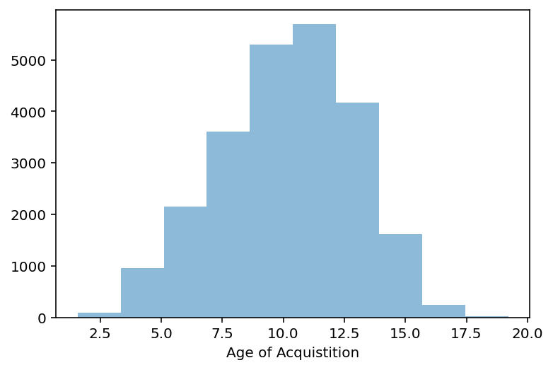

```python
plt.hist(df_words['AoA'], alpha = .5)
plt.xlabel("Age of Acquistition")
```

### Inspecting the data: Concreteness

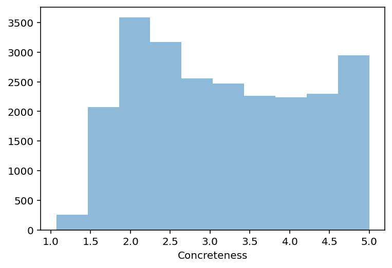

```python
plt.hist(df_words['Conc'], alpha = .5)
plt.xlabel("Concreteness")
```

### Inspecting the data: SUBTLEX

**Check-in: What do you observe about this variable?**

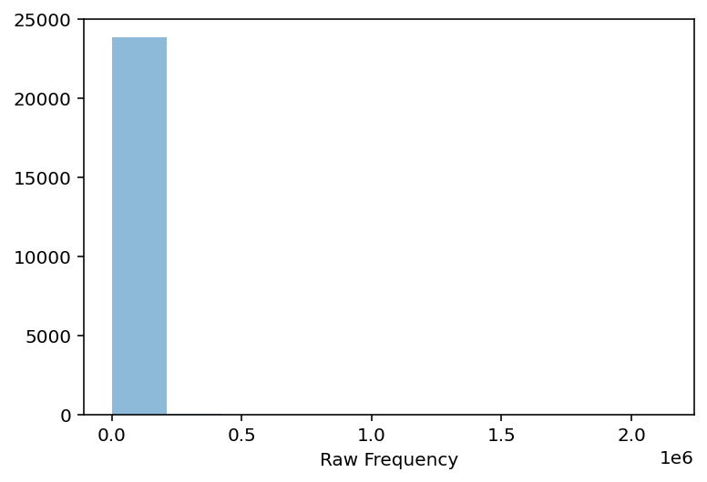

```python
plt.hist(df_words['SUBTLEX'], alpha = .5)
plt.xlabel("Raw Frequency")
```

### Inspecting the data: SUBTLEX

For very right-skewed variables, it is common to **log-transform** them, which makes them slightly more "normal".

- Note that when doing this, we *increment* frequency by 1 (because there are some 0 values).

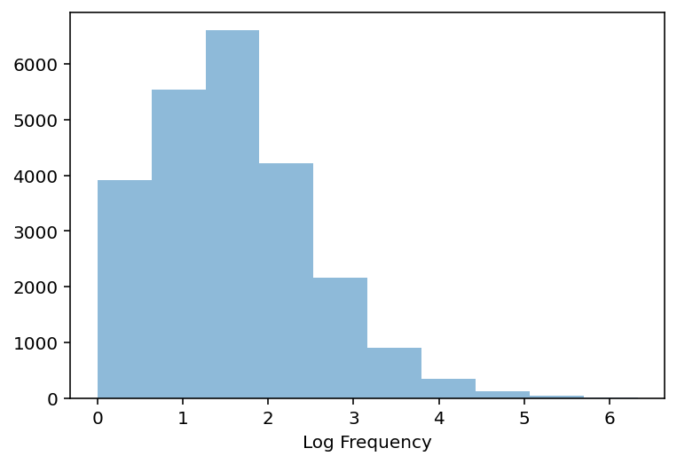

```python
plt.hist(np.log10(df_words['SUBTLEX'] + 1), alpha = .5)
plt.xlabel("Log Frequency")
```

### Building our first model

- Suppose we want to predict **Age of Acquisition**.
- Intuitively, it seems like words about more "concrete" things (tables and chairs) should be learned earlier than more abstract things (justice and ideas).

**Is this true?**

### Regression in Python

We can build a linear model using the `statsmodels` package.

```
import statsmodels.formula.api as smf
smf.ols(
    formula = ... ## model specifications as a string ("Y ~ X + ... ")
    data = ... ## which dataset to use
)
```

### `statsmodels` in action

- In our call to `smf.ols`, we specify that we want to `fit` the model.
- This produces a `fit` model object.

```python
mod = smf.ols(formula='AoA ~ Conc', data=df_words).fit()
mod
```

```
<statsmodels.regression.linear_model.RegressionResultsWrapper at 0x7f7d3c1e7f70>
```

### Inspecting our model

Calling `mod.summary()` gives us a *ton* of information about the model. This is helpful for interpreting your model.

```python
mod.summary()
```

OLS Regression Results

| Dep. Variable: | AoA | R-squared: | 0.143 |
| --- | --- | --- | --- |
| Model: | OLS | Adj. R-squared: | 0.143 |
| Method: | Least Squares | F-statistic: | 3995. |
| Date: | Thu, 11 Aug 2022 | Prob (F-statistic): | 0.00 |
| Time: | 09:58:13 | Log-Likelihood: | -56195. |
| No. Observations: | 23860 | AIC: | 1.124e+05 |
| Df Residuals: | 23858 | BIC: | 1.124e+05 |
| Df Model: | 1 |  |  |
| Covariance Type: | nonrobust |  |  |

|  | coef | std err | t | P>\|t\| | [0.025 | 0.975] |
| --- | --- | --- | --- | --- | --- | --- |
| Intercept | 13.3527 | 0.053 | 251.029 | 0.000 | 13.248 | 13.457 |
| Conc | -1.0079 | 0.016 | -63.207 | 0.000 | -1.039 | -0.977 |

| Omnibus: | 87.064 | Durbin-Watson: | 1.743 |
| --- | --- | --- | --- |
| Prob(Omnibus): | 0.000 | Jarque-Bera (JB): | 83.998 |
| Skew: | -0.125 | Prob(JB): | 5.75e-19 |
| Kurtosis: | 2.851 | Cond. No. | 11.6 |

Notes:  
[1] Standard Errors assume that the covariance matrix of the errors is correctly specified.

## Interpreting our model

- Up next: somewhat rapid run-through of information in `mod.summary()`.
- Don't worry if it seems overwhelming!
  - Lots of information to unpack, we'll take it step-by-step.

### Inspecting our parameters

- We can access these directly by calling `mod.params`.
- Corresponds to $\beta_0$ and $\beta_{conc}$.

```python
mod.params
```

```
Intercept    13.352691
Conc         -1.007884
dtype: float64
```

### Each parameter gets a standard error

- We can access these directly by calling `mod.bse`.
- These **standard errors** can be used to construct a **confidence interval** around our parameter estimate.
  - With more time, we'd also discuss how these are calculated.
  - Assumption: parameters represent a kind of **sample mean**, drawn from a **normal sampling distribution**.

```python
mod.bse
```

```
Intercept    0.053192
Conc         0.015946
dtype: float64
```

### Getting confidence intervals directly

- An easier way to construct the CIs is just to call `mod.conf_int()`
- By default, this assumes $\alpha = .05$, i.e., a $95\%$ CI.
  - Again: crucial assumption is that distribution of **sample statistics** ($\beta$) is **normal**.

```python
mod.conf_int()
```

|  | 0 | 1 |
| --- | --- | --- |
| Intercept | 13.248432 | 13.456951 |
| Conc | -1.039138 | -0.976629 |

### Each parameter also gets a t-statistic

- We can access these directly by calling `mod.tvalues`.
- The **t-statistic** is simply the **parameter** divided by the **standard error**.

$\Large t = \frac{\beta_1}{SE_1}$

- Note: This is how **linear regression** connects to **NHST**!

```python
mod.params / mod.bse
```

```
Intercept    251.028760
Conc         -63.206954
dtype: float64
```

```python
mod.tvalues
```

```
Intercept    251.028760
Conc         -63.206954
dtype: float64
```

### Each parameter also gets a **p-value**.

- We can access these directly by calling `mod.pvalues`.
- The **p-value** is the probability of obtaining a **t-statistic** at least that large, given the appropriate $t$-distribution.
  - $df = n - p$, where $p$ is number of parameters (including intercept).
  - I.e., just a good-old-fashioned **t-test**!

```python
mod.pvalues
```

```
Intercept    0.0
Conc         0.0
dtype: float64
```

### Check-in: What do these parameters mean? How would you write this as a linear equation?

```python
mod.params
```

```
Intercept    13.352691
Conc         -1.007884
dtype: float64
```

### Interpreting our parameters

We could write this as a linear equation:

$\hat{Y} = 13.35 - 1.01*X_{conc}$

Interpretation:

- The predicted `AoA` for words with zero concreteness is $13.35$.
- With each 1-unit increase in `Conc`, predicted `AoA` drops by about 1 year.

### Reporting our parameters

In an academic paper, you'd typically report your coefficients/parameters of interest in the following way:

> Concreteness exhibited a significantly negative relationship with Age of Acquisition [$\beta = -1.01, SE = 0.02, p < .05]$.

You might also report the CI:

> The $95\%$ confidence interval for the Concreteness coefficient was $[-1.04, -0.98]$.

### Interpreting our results

- We originally asked: **are words about more concrete things learned earlier than words about abstract things?**.
- Based on these parameters, that seems *true*.
  - Words with higher concreteness are predicted to have a *lower* `Aoa`.
  - Importantly, the **coefficient** assigned to `Conc` is *significantly negative* ($p < .05$).

```python
print("beta = {x}, p < .05)".format(x=round(mod.params['Conc'], 4)))
```

```
beta = -1.0079, p < .05)
```

## Models as predictive

- Recall that statistical models can also be used to **predict** data.
- This is useful in a couple ways:
  - Practically, we might want to predict $\hat{Y}$ when we don't know the true value of $Y$.
  - Conceptually, our **predictive success** can tell us whether our model is a good one or not.
  - In turn, this *might* suggest we have a good model of the phenomenon we're interested in.
    - Always use caution here: [correlation ≠ causation](https://en.wikipedia.org/wiki/Correlation_does_not_imply_causation), and predictive success ≠ mechanistic insight.

### Extracting model predictions

- Let's see how well our **predictions** stack up against our actual data.
- We can extract each **prediction** $\hat{y}$ for each data point using `mod.predict()`.

```python
y_pred = mod.predict()
y_pred
```

```
array([ 8.46445528,  8.77689923,  8.86760877, ..., 11.90133876,
       11.9114176 , 11.96181178])
```

### Extracting model predictions

- Now we can *plot* our predictions against the real values of $Y$.
- Not perfect by any means––but `AoA` has a lot of variance already.

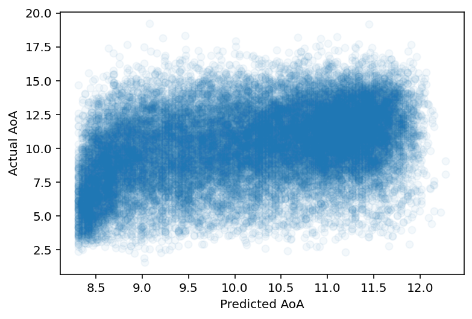

```python
p = plt.scatter(x = y_pred, y = df_words['AoA'], alpha = .05)
t1 = plt.xlabel("Predicted AoA")
t2 = plt.ylabel("Actual AoA")
```

### Check-in: how could we check for possible heteroscedasticity?

## Checking for heteroscedasticity

- We can access the **residuals** of our model using `mod.resid`.
- This looks okay re: heteroscedasticity.

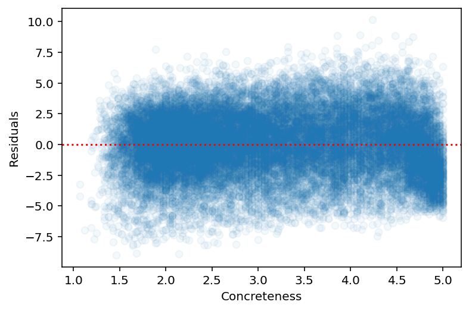

```python
p = plt.scatter(x = df_words['Conc'], y = mod.resid, alpha = .05)
t1 = plt.xlabel("Concreteness")
t2 = plt.ylabel("Residuals")
l = plt.axhline(0, linestyle = "dotted", color = "red")
```

### Check-in: how could we quantify the success of our predictions?

## Evaluating our predictions

There are a few ways to *evaluate* our model:

- $S_{Y|X}$: estimated average prediction error.
- $RSS$: sum of squared deviations between $Y$ and $\hat{Y}$.
- $R^2$: an estimate of the **proportion of variance explained**.

We've already discussed the first two, so let's discuss $R^2$.

## $R^2$: a measure of model fit

- $R^2$: sometimes called the **coefficient of determination**.

$\Large R^2 = 1 - \frac{SS_{resid}}{SS_{total}}$

- Decomposing the formula:
  - $SS_{resid} = RSS$: residual variance, i.e., what's "leftover" after accounting for the model?
  - $SS_{total} = SS_Y$: how much total variance is there to be "explained" in $Y$?
    - Equivalent to **sum of squares** of $Y$.
- If $SS_{resid} = SS_{total}$, then model hasn't explained anything.
- $1 - \frac{SS_{resid}}{SS_{total}}$: what proportion of **total variance** is explained by the model?

## Calculating $R^2$

```python
ss_resid = sum(mod.resid**2)
ss_resid
```

```
155198.01950017206
```

```python
ss_total = sum((df_words['AoA'] - df_words['AoA'].mean())**2)
ss_total
```

```
181186.5585064583
```

```python
r2 = 1 - ss_resid/ss_total
r2
```

```
0.14343524829056176
```

## Extracting $R^2$ using `statsmodels`

We can also extract $R^2$ from our fit `model` object.

```python
mod.rsquared
```

```
0.14343524829054843
```

## Check-in: questions on $R^2$?

# Part 4: Categorical predictors

## Why Categorical predictors?

- So far, we've been assuming $X$ is **continuous**.
- But we're often interested in **categorical** variables.
  - Smoking status (`yes` vs. `no`)
  - Spam status (`spam` vs. `not spam`).
  - Test result (`positive` vs. `negative`).
- When we want to *predict* a (binary) categorical variable, we can use **logistic regression** (coming up).
- But if we're still predicting a continuous variable, we can use linear regression.

## Brief primer on categorical variables

- Categorical variables are typically called **factors**.
- Different categories of this variable are called **levels**.
  - E.g., `spam` vs. `not spam` are **levels** of the variable **Spam Status**.
- For now, we'll focus on **binary** variables, but categorical variables often have ≥2 levels.

## Dataset: word relatedness, in context

- The same word (e.g., "lamb") can have different meanings in different contexts.

> She liked the marinated **lamb**.

> She liked the friendly **lamb**.
- [Trott & Bergen (2021)](https://arxiv.org/abs/2105.13266) collected human judgments of how **related** these uses of the same wordform were in different contexts (dataset on [GitHub](https://github.com/seantrott/raw-c)).
- We'll use this dataset to illustrate categorical predictors.
- Note that this dataset will also be used in **Part 2** of your lab.

### Loading dataset

- Here, we're particularly interested in two variables:
  - `mean_relatedness`: this is what we want to predict!
  - `same`: this tells us whether the two uses of a word belong to the same **meaning** (e.g., baseball bat vs. wooden bat) or different **meanings** (e.g., baseball bat vs. furry bat).

```python
df_rawc = pd.read_csv("data/lab/raw-c.csv")
df_rawc.head(5)
```

|  | word | sentence1 | sentence2 | same | ambiguity_type | mean_relatedness | distance_bert | distance_elmo |
| --- | --- | --- | --- | --- | --- | --- | --- | --- |
| 0 | act | It was a desperate act. | It was a magic act. | False | Polysemy | 2.181818 | 0.204110 | 0.034093 |
| 1 | act | It was a desperate act. | It was a comedic act. | False | Polysemy | 2.000000 | 0.215616 | 0.045927 |
| 2 | act | It was a humane act. | It was a magic act. | False | Polysemy | 2.818182 | 0.191488 | 0.042351 |
| 3 | act | It was a humane act. | It was a comedic act. | False | Polysemy | 2.809524 | 0.225272 | 0.057707 |
| 4 | act | It was a desperate act. | It was a humane act. | True | Polysemy | 3.900000 | 0.167990 | 0.041440 |

### Inspecting `mean_relatedness`.

- What do we notice here?
- What could explain this pattern of ratings?

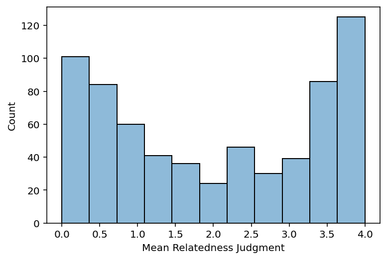

```python
sns.histplot(data = df_rawc, x = 'mean_relatedness', alpha = .5)
plt.xlabel("Mean Relatedness Judgment")
```

### Plotting a relationship between `mean_relatedness` and `same`

How would you interpret this graph?

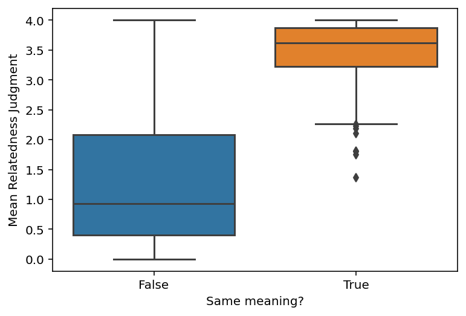

```python
sns.boxplot(data = df_rawc,
           x = 'same',
           y = 'mean_relatedness')
plt.xlabel("Same meaning?")
plt.ylabel("Mean Relatedness Judgment")
```

### Quantifying the effect using regression

- As before, we can construct a **regression model** using `statsmodels`.

```python
mod = smf.ols(formula='mean_relatedness ~ same', data=df_rawc).fit()
mod.summary()
```

OLS Regression Results

| Dep. Variable: | mean_relatedness | R-squared: | 0.524 |
| --- | --- | --- | --- |
| Model: | OLS | Adj. R-squared: | 0.523 |
| Method: | Least Squares | F-statistic: | 737.9 |
| Date: | Thu, 11 Aug 2022 | Prob (F-statistic): | 3.92e-110 |
| Time: | 11:08:55 | Log-Likelihood: | -927.99 |
| No. Observations: | 672 | AIC: | 1860. |
| Df Residuals: | 670 | BIC: | 1869. |
| Df Model: | 1 |  |  |
| Covariance Type: | nonrobust |  |  |

|  | coef | std err | t | P>\|t\| | [0.025 | 0.975] |
| --- | --- | --- | --- | --- | --- | --- |
| Intercept | 1.3215 | 0.046 | 29.011 | 0.000 | 1.232 | 1.411 |
| same[T.True] | 2.1432 | 0.079 | 27.164 | 0.000 | 1.988 | 2.298 |

| Omnibus: | 53.283 | Durbin-Watson: | 0.750 |
| --- | --- | --- | --- |
| Prob(Omnibus): | 0.000 | Jarque-Bera (JB): | 64.661 |
| Skew: | 0.758 | Prob(JB): | 9.10e-15 |
| Kurtosis: | 3.097 | Cond. No. | 2.41 |

Notes:  
[1] Standard Errors assume that the covariance matrix of the errors is correctly specified.

### Check-in: what would be most useful to inspect from this summary?

### Quantifying model fit

- $R^2$ will tell us how much variance in `mean_relatedness` is explained by `same`.
- In this case, quite a lot!

```python
mod.rsquared
```

```
0.524110337262857
```

### Inspecting our parameters

- What do these parameters tell us?
- How would we write this in a linear equation?

```python
mod.params
```

```
Intercept       1.321497
same[T.True]    2.143177
dtype: float64
```

### Categorical variables in a linear equation

Our linear equation takes the form:

$\Large \hat{Y} = 1.32 + 2.14X_{same}$

**But what exactly does this mean?**

### Contrast coding

- There are [many ways to *code* a categorical variable in a regression model](https://marissabarlaz.github.io/portfolio/contrastcoding/).
- One of the most common approaches is called **treatment coding**.
- For a binary variable, this means:
  - Treat each level of the variable as `1` (`True`) vs. `0` (e.g., `False`).
  - Select the *mean* of one level (e.g., `0`) to be the **intercept**.
  - The **slope** then indicates the **difference in means** between the intercept and the other level (e.g., `1`).

### Treatment coding in the linear equation

First, we turn our `same` variable into `1` and `0`:

$ \begin{equation} X= \begin{cases} 0, & \text{if}\ X=False \\ 1, & \text{if}\ X=True \\ \end{cases} \end{equation}$

Now, let's consider the linear equation once more:

$\Large \hat{Y} = 1.32 + 2.14X_{same}$

- What happens when $X_{same = False}$?
- What happens when $X_{same = True}$?

### Treatment coding in the linear equation

$\Large \hat{Y} = 1.32 + 2.14X_{same}$

- If $X_{same = False}$...
  - Our equation reduces to: $\hat{Y} = 1.32 + 2.14*0 = 1.32$
  - This is just the **intercept**, e.g., `mean_relatedness` when `X = False`.
- If $X_{same = True}$...
  - Our equation reduces to: $\hat{Y} = 1.32 + 2.14*1 = 3.46$
  - This should be equal to `mean_relatedness` when `X = True`!

### Checking our work

- Let's inspect the **mean** of each level to make sure our numbers match up.
- It looks like they do!

```python
df_rawc[['same', 'mean_relatedness']].groupby('same').mean()
```

| same | mean_relatedness |
| --- | --- |
| False | 1.321497 |
| True | 3.464674 |

### Checking our work (pt. 2)

- Further, the **difference in means** should be equal to the **slope** from the model.

```python
3.464674 - 1.321497
```

```
2.143177
```

```python
mod.params['same[T.True]']
```

```
2.1431774683906255
```

### Questions on categorical predictors?

# Conclusion

- Lots more to unpack with **linear regression**.
- But hopefully, this was a rapid-but-useful intro to:
  - **Explaining** the motivation for building statistical models in general.
  - **Describing** the basic assumptions (and limitations) of linear regression.
  - **Explaining** the concept of *prediction error* and why it matters for statistics.
  - **Implementing** linear regression in Python using `statmodels`.
  - **Interpret** coefficients for both *continuous* and *categorical* predictors.